# CineVision - Clustering, Apriori, PCA

Flavio Galán, José Prince

2025-02-16

[Repositorio](https://github.com/ElrohirGT/Proyecto1_MineriaDeDatos.git)

# Clustering

## Prepocesamiento de los datos

Acá podemos encontrar las siguientes variables: **id, budget, genres, homePage, productionCompany, productionCompanyCountry, productionCountry, revenue, runtime, video, director, actors, actorsPopularity, actorsCharacter, originalTitle, title, originalLanguage, popularity, releaseDate, voteAvg, voteCount, genresAmount, productionCoAmount, productionCountriesAmount, actorsAmount, castWomenAmount, castMenAmount**.

Para el análisis de los datos solo se necesitaran de las variables que se categorizaron como cuantitativas durante el análisis exploratorio. Se toma esta decisión debido a que en los métodos de clustering a utilizar se basan en variables cuantitativas por lo que para evitar ambiguedades se omite el agrupamiente de este tipo de variables y obtener un mejor resultado en el agrupamiento de datos. De igual forma otra variable que no aporta información al agrupamiento es justamente la que contiene el id de los datos, en este caso siendo “id”, esto se debe a que esta variable al agruparla no aporta ningún tipo de información.

Obteniendo las siguientes columnas a analizar: **budget, revenue, runtime, popularity, voteAvg, voteCount, genresAmount, productionCoAmount, productionCountriesAmount, actorsAmount**.

Viendo con más detalle cada una de las variables escogidas.

- budget: el presupuesto utilizado para la película.
- revenue: las ganancias de la película.
- runtime: duración total de la película.
- popularity: índice de popularidad de la película, calculada semanalmente.
- voteAvg: promedio de votos para la película.
- voteCount: número de votos para la película.
- genresAmount: cantidad total de generos destinados a una película.
- productionCoAmount: cantidad de compañías productoras que participaron en la película.
- productionCountriesAmount: cantidad de países en los que se rodó la película.
- actorsAmount: cantidad de personas que actuan en la película.

## Hopkings y VAT

```
## Estadistico de Hopkins:  1
```

Analizando el estadístico de Hopkings obtenemos que su valor es de **1**, esto nos indica que los datos tienen una fuerte estructura de agrupamiento. Para corrobar que existan grupos de datos, se realiza la “Evaluación Visual de Tendencia”.

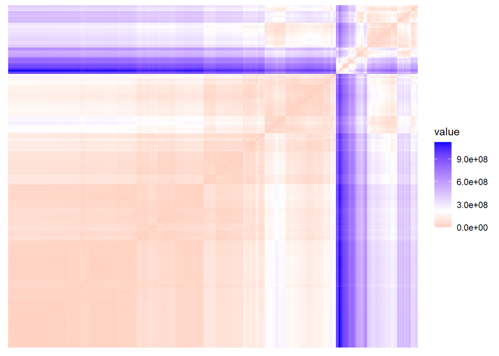

La EVT (evaluación visuald e tendencia) se hizo con una muestra de 300 debido a que el dataset era muy grande para procesarlo por completo y vemos que existe una tendencia de agrupamiento para los datos.

## Método de codo

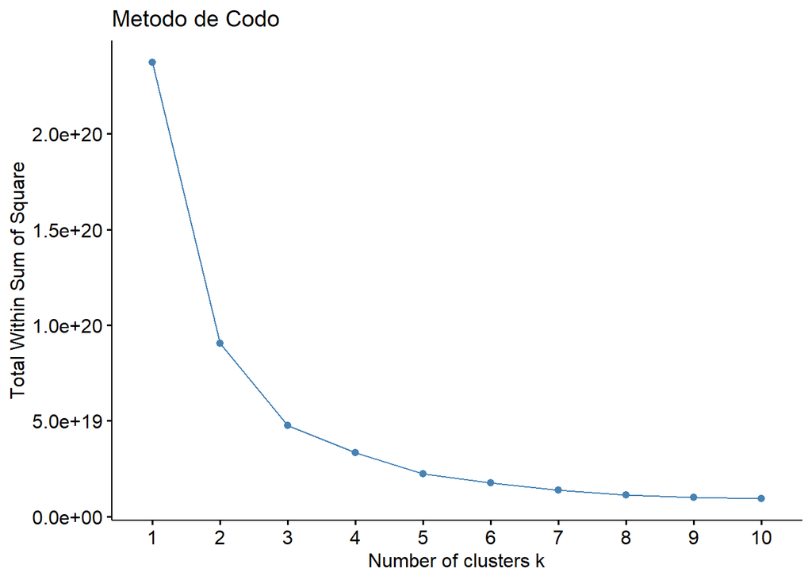

## K-medias y CLustering jerárquico

Este es el gráfico obtenido de K-medias:

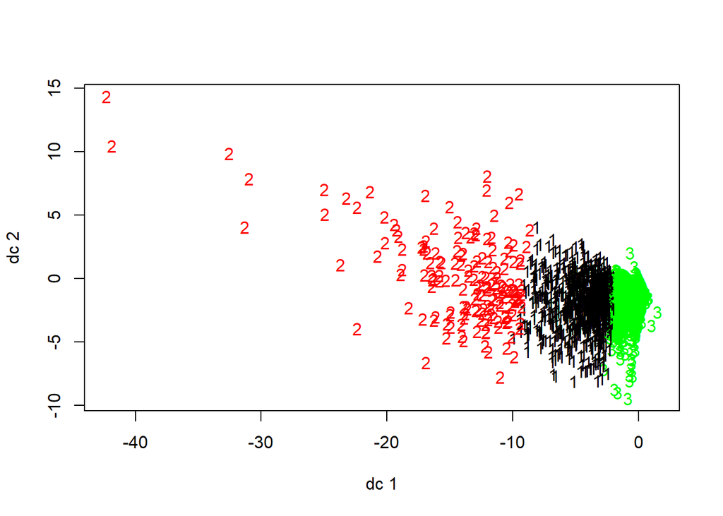

Este es el el dendograma que se genera para el clustering jerárquico:

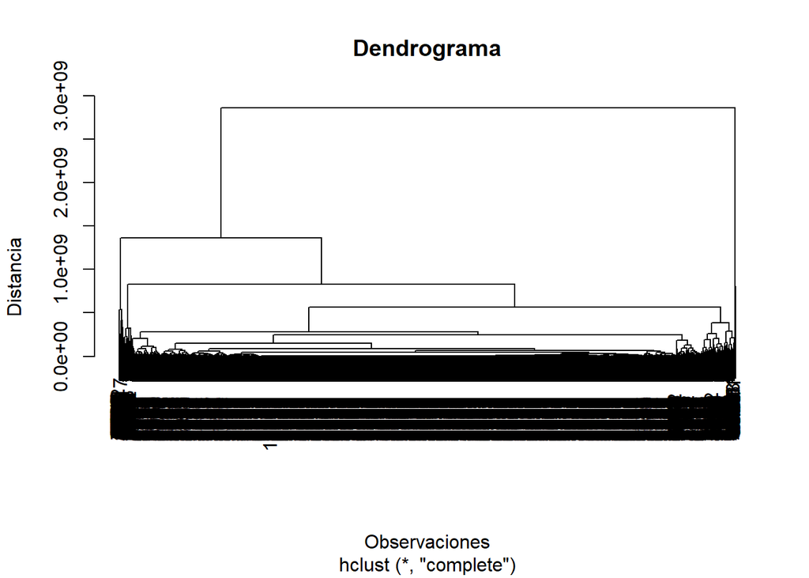

Haciendo una comparación entre la gráfica obtenida por K-Means y por el dendograma del agrupamiento jerarquico podemos ver que los datos se separan en tres grupos principales, indicado anteriormente por el método de codo. A su vez podemos ver que uno de los grupos se encuentra más disperso, debido a las limitaciones de software esto no es visible en el dendograma pero sí en K-means.

## Método de la silueta

Este método nos ayudará a determinar la calidad del agrupamiento. Midiendo qué tan bien están agrupados los puntos dentro de su cluster y qué tan separados están de otros clusters. A continuación se muestra el gráfico del método de la silueta para los métodos de clusterings anteriores.

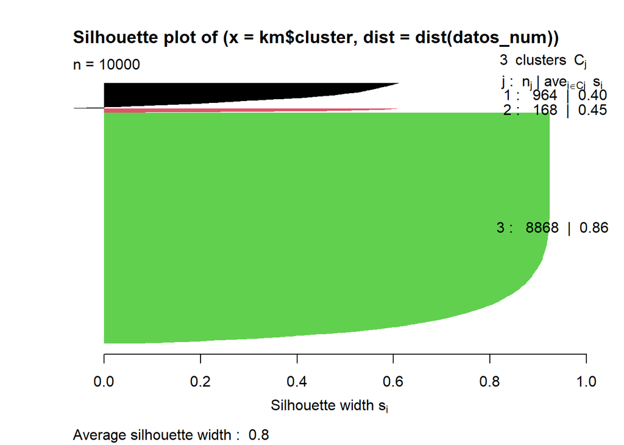

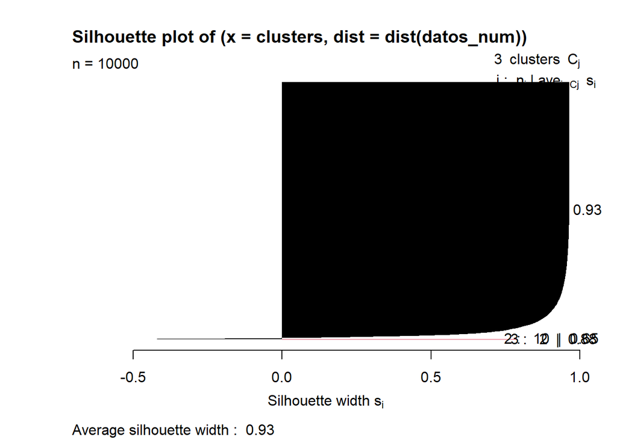

Se puede apreciar que ambos métodos de clustering agrupan correctamente cada punto en su respectivo cluster. Esto lo sabemos cuando vemos el valor de “average silhouette width” que es 0.8 y 0.93 para K-means y hc (hierarchy clustering); si este valor hubiera sido cercano a 0 nos indicaria que el clustering no es muy claro o no esta bien definido, en caso de ser un número negativo sugiere que la asignación de los clusters podría ser incorrecta. Ya simplemente comparando los “average silhouette width” entre los diferentes métodos vemos que el hc es el mejor método.

## Interpretación de los grupos

```
##   Group.1    budget    revenue  runtime popularity  voteAvg voteCount
## 1       1  18286275   54522606 100.2148    50.2754 6.482149  1324.025
## 2       2 228000000 1716242305 139.3000  1080.7464 7.540000 15450.600
## 3       3 296500000 2822523384 171.5000   490.4720 7.900000 22476.000
##   genresAmount productionCoAmount productionCountriesAmount actorsAmount
## 1     2.595515           3.171706                  1.751402     2150.153
## 2     3.400000           3.000000                  1.400000       80.200
## 3     3.500000           2.500000                  1.500000       70.000
```

# Reglas de Asociación

Obtenga reglas de asociación interesantes del conjunto de datos usando el algoritmo “A priori”. Recuerde discretizar las variables numéricas. Genere reglas con diferentes niveles de confianza y soporte. Discuta los resultados. Si considera que debe eliminar variables porque son muy frecuentes y con eso puede recibir más “insights” de la generación de reglas. Hágalo y discútalo.

```
## Apriori
##
## Parameter specification:
##  confidence minval smax arem  aval originalSupport maxtime support minlen
##         0.8    0.1    1 none FALSE            TRUE       5    0.01      2
##  maxlen target  ext
##      10  rules TRUE
##
## Algorithmic control:
##  filter tree heap memopt load sort verbose
##     0.1 TRUE TRUE  FALSE TRUE    2    TRUE
##
## Absolute minimum support count: 100
##
## set item appearances ...[0 item(s)] done [0.00s].
## set transactions ...[24 item(s), 10000 transaction(s)] done [0.00s].
## sorting and recoding items ... [12 item(s)] done [0.00s].
## creating transaction tree ... done [0.00s].
## checking subsets of size 1 2 3 4 5 6 done [0.01s].
## writing ... [455 rule(s)] done [0.00s].
## creating S4 object  ... done [0.00s].
```

```
##       lhs                      rhs                support confidence coverage      lift count
## [1]   {budget=Muy Bajo,
##        revenue=Muy Bajo,
##        voteCount=Moderados} => {voteAvg=Buena}     0.0114  0.8906250   0.0128 3.4749317   114
## [2]   {budget=Muy Bajo,
##        revenue=Muy Bajo,
##        popularity=Baja,
##        voteCount=Moderados} => {voteAvg=Buena}     0.0114  0.8906250   0.0128 3.4749317   114
## [3]   {budget=Muy Bajo,
##        revenue=Muy Bajo,
##        runtime=Corto,
##        voteCount=Moderados} => {voteAvg=Buena}     0.0114  0.8906250   0.0128 3.4749317   114
## [4]   {budget=Muy Bajo,
##        revenue=Muy Bajo,
##        runtime=Corto,
##        popularity=Baja,
##        voteCount=Moderados} => {voteAvg=Buena}     0.0114  0.8906250   0.0128 3.4749317   114
## [5]   {budget=Muy Bajo,
##        voteCount=Moderados} => {voteAvg=Buena}     0.0120  0.8695652   0.0138 3.3927632   120
## [6]   {budget=Muy Bajo,
##        popularity=Baja,
##        voteCount=Moderados} => {voteAvg=Buena}     0.0120  0.8695652   0.0138 3.3927632   120
## [7]   {budget=Muy Bajo,
##        runtime=Corto,
##        voteCount=Moderados} => {voteAvg=Buena}     0.0120  0.8695652   0.0138 3.3927632   120
## [8]   {budget=Muy Bajo,
##        runtime=Corto,
##        popularity=Baja,
##        voteCount=Moderados} => {voteAvg=Buena}     0.0120  0.8695652   0.0138 3.3927632   120
## [9]   {budget=Bajo,
##        revenue=Muy Bajo,
##        popularity=Baja,
##        voteCount=Pocos}     => {voteAvg=Regular}   0.0334  0.8720627   0.0383 1.2060056   334
## [10]  {budget=Bajo,
##        revenue=Muy Bajo,
##        runtime=Corto,
##        popularity=Baja,
##        voteCount=Pocos}     => {voteAvg=Regular}   0.0334  0.8720627   0.0383 1.2060056   334
## [11]  {budget=Bajo,
##        popularity=Baja,
```

[output cut: 1248 more lines]

```
##        voteAvg=Buena,
##        voteCount=Moderados} => {budget=Muy Bajo}   0.0114  0.8142857   0.0140 0.8727607   114
## [451] {revenue=Muy Bajo,
##        runtime=Corto,
##        popularity=Baja,
##        voteAvg=Buena,
##        voteCount=Moderados} => {budget=Muy Bajo}   0.0114  0.8142857   0.0140 0.8727607   114
## [452] {budget=Bajo}         => {voteCount=Pocos}   0.0399  0.8028169   0.0497 0.8303857   399
## [453] {budget=Bajo,
##        runtime=Corto}       => {voteCount=Pocos}   0.0399  0.8028169   0.0497 0.8303857   399
## [454] {budget=Bajo,
##        popularity=Baja}     => {voteCount=Pocos}   0.0397  0.8020202   0.0495 0.8295616   397
## [455] {budget=Bajo,
##        runtime=Corto,
##        popularity=Baja}     => {voteCount=Pocos}   0.0397  0.8020202   0.0495 0.8295616   397
```

Como se puede ver encuentra muchas reglas dentro del conjunto de datos, sin embargo, varias son subconjuntos de otras reglas que se pueden encontrar más abajo. Lo que lleva a muchas repeticiones.

Algunas reglas interesantes que pude encontrar son por ejemplo:

- Tener un Budget muy bajo, una popularidad baja pero un voteCount moderado generalmente lleva a un voteAvg bueno! Esta regla se cumple con casi un 90% de confianza y tiene un soporte del 0.0114 en todo el dataset. El soporte puede ser bajo pero es que justamente la regla está hablando de películas underground que normalmente pasan desapercibidas.
- Aunque tengas un budget muy bajo y un runtime corto si tu popularidad tambiés es baja no importa que tu average de votos sea bueno, la data predice que tu revenue será muy bajo con un 99% de confianza y un 0.23 de representación. Por lo tanto esto nos dice que la popularidad es importante!

# PCA

**3.1. Estudie si es posible hacer transformaciones en las variables categóricas para incluirlas en el PCA, ¿valdrá la pena?**

Sí se puede realizar PCA en variables categóricas aunque solamente si éstas son traducibles a números ordenados, si en su lugar se tienen propiedades como: “verde”, “rojo”, “azul” y no implican un orden entre ellas entonces no es posible.

Dentro de las variables que tenemos en el data set de películas, ninguna se puede traducir a números ordenados puesto que las variables no son ordenadas.

**3.2. Estudie si es conveniente hacer un Análisis de Componentes Principales. Recuerde que puede usar el índice KMO y el test de esfericidad de Bartlett.**

```
## Kaiser-Meyer-Olkin factor adequacy
## Call: KMO(r = cor(datos_num))
## Overall MSA =  0.71
## MSA for each item =
##                        id                    budget                   revenue
##                      0.70                      0.75                      0.68
##                   runtime                popularity                   voteAvg
##                      0.77                      0.65                      0.52
##                 voteCount              genresAmount        productionCoAmount
##                      0.75                      0.67                      0.58
## productionCountriesAmount              actorsAmount
##                      0.64                      0.62
```

```
## $chisq
## [1] 22861.17
##
## $p.value
## [1] 0
##
## $df
## [1] 55
```

**3.3. Haga un análisis de componentes principales con las variables numéricas, discuta los resultados e interprete los componentes.**

```
## Importance of components:
##                           PC1    PC2    PC3     PC4     PC5     PC6     PC7
## Standard deviation     1.6867 1.0942 1.0613 1.01912 0.99178 0.98575 0.96059
## Proportion of Variance 0.2586 0.1088 0.1024 0.09442 0.08942 0.08834 0.08389
## Cumulative Proportion  0.2586 0.3675 0.4699 0.56428 0.65370 0.74204 0.82592
##                            PC8     PC9    PC10    PC11
## Standard deviation     0.87700 0.80274 0.56398 0.42812
## Proportion of Variance 0.06992 0.05858 0.02892 0.01666
## Cumulative Proportion  0.89584 0.95442 0.98334 1.00000
```

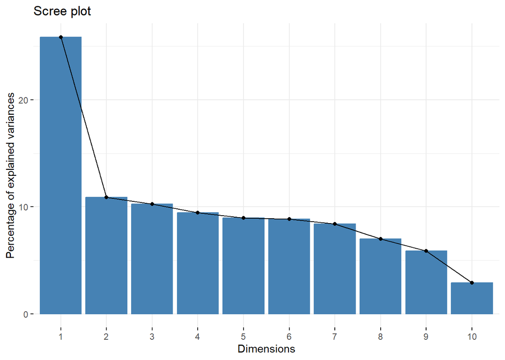

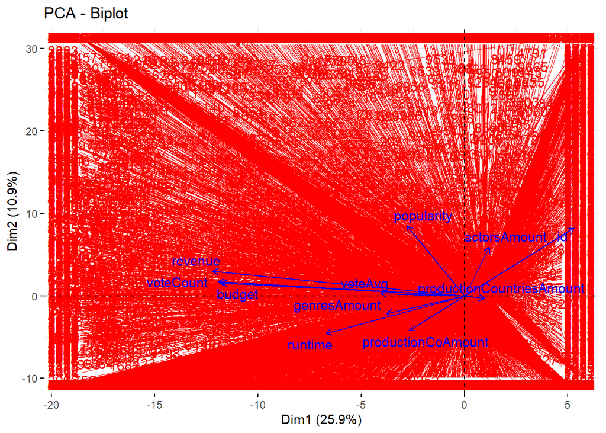

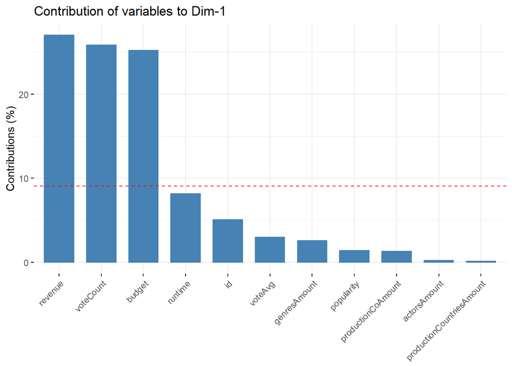

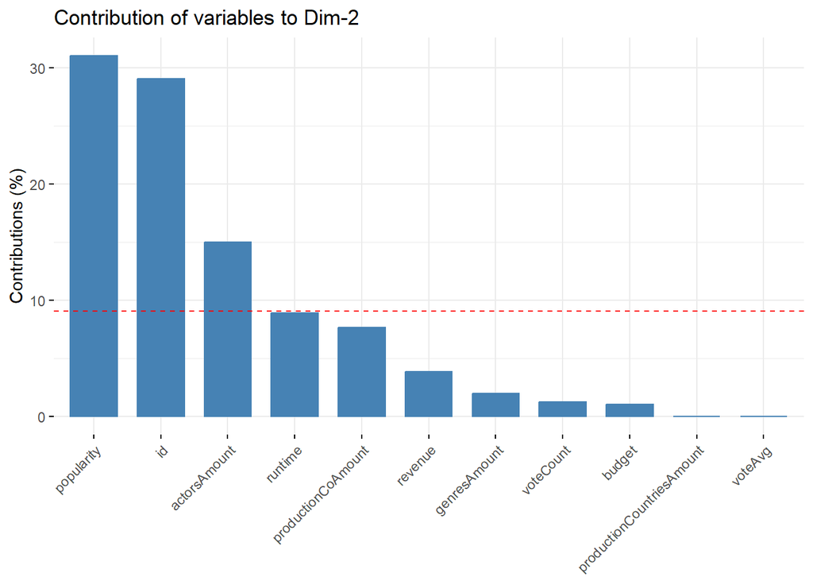

Como se puede ver por el resultado del PCA, se puede explicar más del 70% de la varianza usando las primeras 6 variables. Obteniendo las cargas factoriales tenemos:

```
##                                   PC1         PC2          PC3         PC4
## id                         0.22510188  0.53892717 -0.327944174  0.03453058
## budget                    -0.50192087  0.10230674  0.132510104  0.22890104
## revenue                   -0.51975896  0.19704447  0.092214553  0.11844942
## runtime                   -0.28592452 -0.29847178 -0.382327983 -0.18326440
## popularity                -0.11914942  0.55732377 -0.240977497  0.02029019
## voteAvg                   -0.17271957  0.01794925 -0.394635829 -0.71735427
## voteCount                 -0.50801701  0.11218342  0.006706558 -0.01797350
## genresAmount              -0.16078460 -0.14203854  0.327440603 -0.06705790
## productionCoAmount        -0.11510918 -0.27715619 -0.363503261  0.37927780
## productionCountriesAmount  0.04130211 -0.02035200 -0.434436017  0.48405048
## actorsAmount               0.05084078  0.38763014  0.279779001 -0.02847243
##                                   PC5         PC6
## id                         0.08553915  0.01838920
## budget                    -0.04371850  0.03789535
## revenue                   -0.16171705  0.02024138
## runtime                   -0.06795210 -0.09639045
## popularity                 0.36709616  0.36554028
## voteAvg                    0.07923306 -0.23921332
## voteCount                 -0.17579236 -0.04323052
## genresAmount               0.74103764 -0.14514778
## productionCoAmount         0.46738737 -0.09695689
## productionCountriesAmount -0.13726007 -0.42135171
## actorsAmount               0.04041501 -0.76668610
```

PC1: Budget, Revenue, VoteCount PC2: Id, Popularity, ActorsAmount PC3: ProductionCountriesAmount, Runtime, VoteAVG PC4: VoteAVG, ProductionCountriesAmount PC5: GenresAmount, ProductionCoAmount PC6: ActorsAmount, ProductionCountriesAmount

No todas las variables que da como resultado el PCA tienen un sentido puesto que realmente es solo una forma de minimizar el espacio en el que estamos trabajando los datos. Sin embargo algunas interpretaciones que veo por las componentes principales de cada variable superior son:

- PC1: Éxito Financiero de una película
- PC5: Qué tan amigable al público general es la película

# Conclusiones

El clustering de los datos nos indicó que es óptimo separar el conjunto de datos en 3 grupos:

- Group 1: Identificado principalmente por su baja cantidad de dinero presupuestado, en general represeta al conjunto de películas independientes u *underground*.
- Grupo 3: Representa a todos los blockbusters del cine, proyectos/franquicias enormes con una gran cantidad de presupuesto y en general, duración y cuenta de votos más altos.
- Grupo 2: El grupo dos representa todas las películas con presupuesto medio/alto cuya principal diferencia respecto al grupo 3 es su popularidad, pues su media es de lejos la más alta en este aspecto.

Pasando al análisis de componentes principales o PCA podemos afirmar que 6 u 8 es el número ideal para la reducción, en este análisis se decidió usar 6 representando así más del 70% de la variabilidad de los datos. Muchas de las variables generadas por el PCA fueron realmente combinaciones lineales solamente sin un claro significado en el mundo real, sin embargo se pudieron encontrar 2 variables que sería interesante explorar más a fondo en otro análisis a futuro:

- PC1: Representando el éxito financiero de una película.
- PC5: Qué tan amigable al público general es la película.

Regresando al análisis a priori que genera reglas en base a los datos, las dos más interesantes fueron:

- Tener un Budget muy bajo, una popularidad baja pero un voteCount moderado generalmente lleva a un voteAvg bueno! Esta regla se cumple con casi un 90% de confianza y tiene un soporte del 0.0114 en todo el dataset. El soporte puede ser bajo pero es que justamente la regla está hablando de películas underground que normalmente pasan desapercibidas.
- Si tienes un budget muy bajo y un runtime corto no importa que consigas un average de votos bueno, si no logras subir tu popularidad, la data predice que tu revenue será muy bajo con un 99% de confianza y un 0.23 de representación. Por lo tanto esto nos dice que la popularidad es importante!

Finalmente nuestras sugerencias principales a CineVisión serían:

- La popularidad de una película es un factor clave en el éxito en revenue obtenido de un proyecto! No escatimen en el marketing y el desarrollo de una historia/proyecto de calidad aunque tengan un budget bajo.
- Solo hay 3 grupos de proyectos dentro de los datos, existen varias estrategias para entrar a distintas secciones del mercado, intenta enfocarte en uno de los 3 sub-mercados y recuerda, es mejor ser cabeza de ratón que cola de león.
- En futuros análisis recomendamos investigar cómo se representa el éxito financier de una película respecto a qué tan amigable es para el público general, pueden usar la misma minimización de PCA que utilizamos en este estudio.